# Spatial point processes

David Murrell, UCL Centre for Biodiversity and Environment Research

## Learning objectives

The three main objectives of this session are

1. What are point processes?
2. Hypothesis testing using spatial statistics
3. Homogeneous and inhomogeneous spatial processes

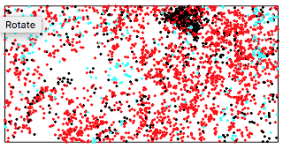

```r
knitr::include_graphics(".\\img\\spatialstats3\\pp2.png")
```

## 1. Point processes

- “Points” described by x- y-coordinates
  - locations of discrete events
- Wide range of applications
  - ecology (esp. plant ecology); astronomy (clustering within galaxies); urban planning (household pattern); crime (locations of different crimes); epidemiology (disease spread)
- Points often have attributes **marks**
  - species names, size attribute, type of crime, etc.
- Normally, complete sampling within area
  - points are presences; gaps are absences

### Questions/Objectives

- Determine if there is a tendency of events to exhibit a systematic pattern over an area as opposed to being randomly distributed
- Does a pattern exhibit clustering or regularity?
- Is there ‘attraction’ or ‘inhibition’?
- Over what spatial scales do patterns exist?
- Relate these to known processes?

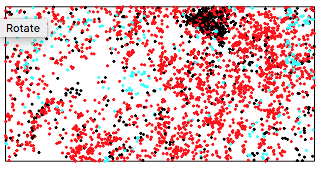

```r
knitr::include_graphics(".\\img\\spatialstats3\\pp2.png")
```

## Three general patterns

1. **Random** (aka *Complete Spatial Randomness* or **CSR**) -points are independently arranged across the landscape.
2. **Uniform/segregated** -points are evenly spaced.
3. **Aggregated/Clustered** -many points are concentrated close together, and large areas that contain very few, if any, points.

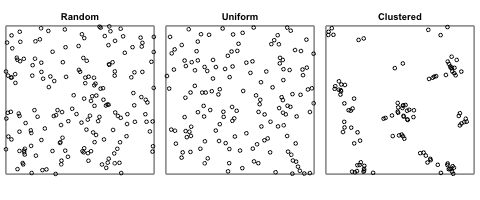

```r
knitr::include_graphics(".\\img\\spatialstats3\\fig.png")
```

**CSR** is often the *null hypothesis*.

- CSR = Poisson process
- Number of points in a region of finite size is a random variable with a Poisson distribution

## 2. Preliminaries

- We will need to use two libraries:
  1. **spatstat** which is very large and is the go-to library for handling and analysing point pattern data;
  2. **GET** which is a specific library for correctly generating confidence intervals for functional data (ie where something of interest is a function of space/time/etc.). This will be used when we start testing some hypotheses about our data.

There is a very comprehensive set of manuals/guides/tutorials for *spatstat* that can easily be found using your favourite search engine.

```r
#NOT RUN
#If you don't have the libraries then you will need to install them first
#install.packages("spatstat")
#install.packages("GET")

#Load up the libraries
library(spatstat)
library(GET)
```

## 3. The Data

We now read in the tropical forest dataset from the Barro Colorado Island, off the coast of Panama. This is a well studied system where each tree within a 50Ha plot has been monitored in 1981 and then every 5 years since 1985. We will use the most recent census that is available. More details can be found here http://ctfs.si.edu/webatlas/datasets/bci/

```r
load(".\\data\\bci.full7.rdata")
```

It is always good to inspect the dataset. Here we find there are a lot of variables that have been measured, including species name, x- and x-coordinates, status (alive or dead), circumference of trunk at breast height (DBH), etc.

```r
head(bci.full7)
```

```
##   treeID stemID    tag StemTag     sp quadrat    gx    gy MeasureID
## 1      1     NA -05599    <NA> swars1    4007 800.2 152.2        NA
## 2      2     NA -22851    <NA> hybapr    0718 151.5 378.8        NA
## 3      3     NA -24362    <NA> aegipa    0417  95.2 357.5        NA
## 4      4     NA -26589    <NA> beilpe    0007  11.7 151.1        NA
## 5      5     NA -26590    <NA> faraoc    0004   7.7  96.2        NA
## 6      6     NA -26703    <NA> hybapr    0210  50.1 215.4        NA
##   CensusID dbh  pom hom ExactDate DFstatus codes nostems     date status
## 1       NA  NA <NA>  NA      <NA>     dead  <NA>      NA 18465.07      D
## 2       NA  NA <NA>  NA      <NA>     dead  <NA>      NA 18329.00      D
## 3       NA  NA <NA>  NA      <NA>     dead  <NA>      NA 18316.05      D
## 4       NA  NA <NA>  NA      <NA>     dead  <NA>      NA 18295.61      D
## 5       NA  NA <NA>  NA      <NA>     dead  <NA>      NA 18288.57      D
## 6       NA  NA <NA>  NA      <NA>     dead  <NA>      NA 18300.45      D
##   agb
## 1   0
## 2   0
## 3   0
## 4   0
## 5   0
## 6   0
```

```r
#Get rid of dead trees
bci.alive<-subset(bci.full7, DFstatus=="alive")

#Total number of alive trees in this census
length(bci.alive$gx)
```

```
## [1] 221758
```

```r
#Let's get the number species by counting up the number of species names
sp_names<-unique(bci.alive$sp)

#How many are in this forest plot?
length(sp_names)
```

```
## [1] 302
```

```r
#Now choose a species
s<-1

#Get the species name (this is the abbreviated name)
print(sp_names[s])
```

```
## [1] "gustsu"
```

```r
#Subset the full dataset to get only this species
sp1<-subset(bci.alive, sp==sp_names[s])

#Check the file looks ok
head(sp1, n=5)
```

```
##     treeID stemID    tag StemTag     sp quadrat    gx    gy MeasureID
## 19      19      1 000002         gustsu    4924 994.1 488.3         1
## 58      58      1 000043         gustsu    4917 998.2 344.7        34
## 61      61      1 000046         gustsu    4917 980.1 341.1        37
## 119    119      1 000104         gustsu    4908 982.9 173.9        74
## 127    127      1 000112         gustsu    4908 995.8 165.4        79
##     CensusID dbh pom hom  ExactDate DFstatus  codes nostems  date status
## 19       171 308   3 3.0 2010-09-13    alive B,cylY       1 18518      A
## 58       171 305 1.3 1.3 2010-09-16    alive   <NA>       1 18521      A
## 61       171 314 1.3 1.3 2010-09-16    alive   <NA>       1 18521      A
## 119      171 222 1.3 1.3 2010-09-07    alive   <NA>       1 18512      A
## 127      171 215 1.3 1.3 2010-09-07    alive   <NA>       1 18512      A
##           agb
## 19  0.7491262
## 58  0.7304636
## 61  0.7872836
## 119 0.3197238
## 127 0.2939528
```

```r
#What is the abundance?
length(sp1$treeID)
```

```
## [1] 745
```

## What patterns should we expect?

Trees

1. Don’t move
   - cannot avoid competitors once they germinate
2. Compete with their nearby neighbours
   - light, soil nutrients
   - competition of nearby neighbours leads to inhibition of trees at short distances?
3. Seeds disperse relatively short distances from parent
   - clustering of trees at short distances?

Clustered? Segregated? Both?

Weaker clustering = weaker competition?

## 4. Creating a point pattern for your species

The example species chosen is *Gustavia* *superba*, which is a tree that likes disturbed areas (https://en.wikipedia.org/wiki/Gustavia_superba). We now need to create a point pattern object for this species using the **spatstat** library. All we need are the x- and y-coordinates for each individual and the limits that describe the plot area. Fortunately the plot is a rectangle of dimensions 1000 x 500 m (ie 50 Ha), so this is rather straighforward.

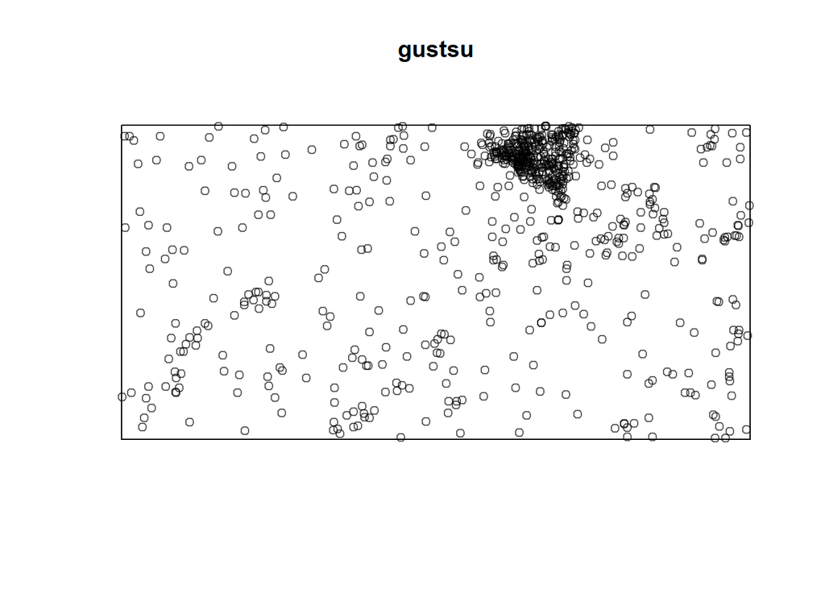

```r
#Create the point pattern object for the chosen species
sp1_pp<-ppp(sp1$gx, sp1$gy, c(0,1000), c(0,500))

#Plot the point pattern
plot(sp1_pp, main=sp_names[s])
```

Compute $\lambda$, which is the intensity of the process and $\lambda = \frac{n}{A}$ where $n$ is the number of points (trees), and $A$ is the area of the plot.

```r
lam<-length(sp1$treeID)/(1000*500)
print(lam)
```

```
## [1] 0.00149
```

What does a ‘random’ pattern for *Gustavia* look like?

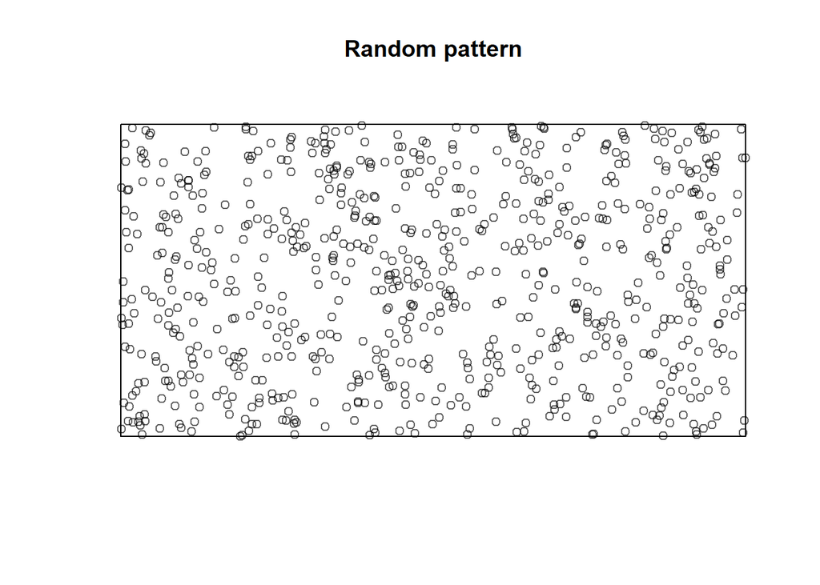

```r
plot(rpoispp(lam, win=owin(c(0,1000),c(0,500))), main="Random pattern")
```

## 5. Point pattern analysis using descriptive statistics

Today we will use the well established Ripley’s K function to analyse the data. More details can be found here https://en.wikipedia.org/wiki/Spatial_descriptive_statistics.

### 5.1 Ripley’s K function

- The number of pairs of points at a given scale
- Sum neighbours of all individuals within radius $r$
- $\hat{K}$ is a function (of $r$)

```r
list.files()
```

[output not shown]

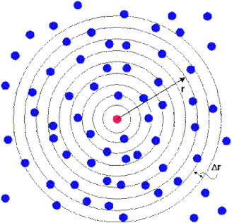

```r
knitr::include_graphics(".\\img\\spatialstats3\\ripleysK.gif")
```

- Mathematically:

```
$\hat{K}(r)$ =  $\lambda^{-1}  \sum_{i}^{n}\sum_{j \neq i}^{n} \frac{1}{W_i} \frac{I(d_{ij} < r)}{n}$
```

where $\lambda$ is the intensity, often $\frac{n}{A}$; $\frac{1}{W_i}$ is a weighting to account for edge effects; $I(d_{ij})$ is the indicator function to count $j$ only if it is within distance $r$

- Expected value under CSR: $\pi r^2$

### 5.2 Hypothesis testing

- $\hat{K}$ is a **non-parametric** summary statistic
- Monte Carlo approach
  1. Sample the data under assumptions of null hypothesis
     - **randomise** the locations of the events to achieve CSR
  2. Compare observation to sample distribution: is it an outlier?
- In $R$:
  1. Produce $s$ random patterns of *Gustavia*
  2. For each pattern $P$, estimate $\hat{K}(r)$
  3. Construct a confidence envelope containing 95% least extreme $\hat{K}(r)$
  4. Plot the envelope and the realworld *Gustavia* $\hat{K}(r)$
  5. Where the observed $\hat{K}(r)$ lies outside of the envelope, the null hypothesis can be rejected at the 5% level of significance, for that spatial scale $r$

### 5.3 Homogeneous processes

The first set of analyses makes the simplifying assumption that the *underlying distribution of trees is homogeneous* across the plot. We can easily test against the null hypothesis that the distribution of trees is in fact independent of one another using Ripley’s K.

First we estimate the K-function for the data. Note there are a number of ways of dealing with **edge effects** and that they give slightly different estimates. The K-function assuming a Poisson distribution is also given and stored as $pois.

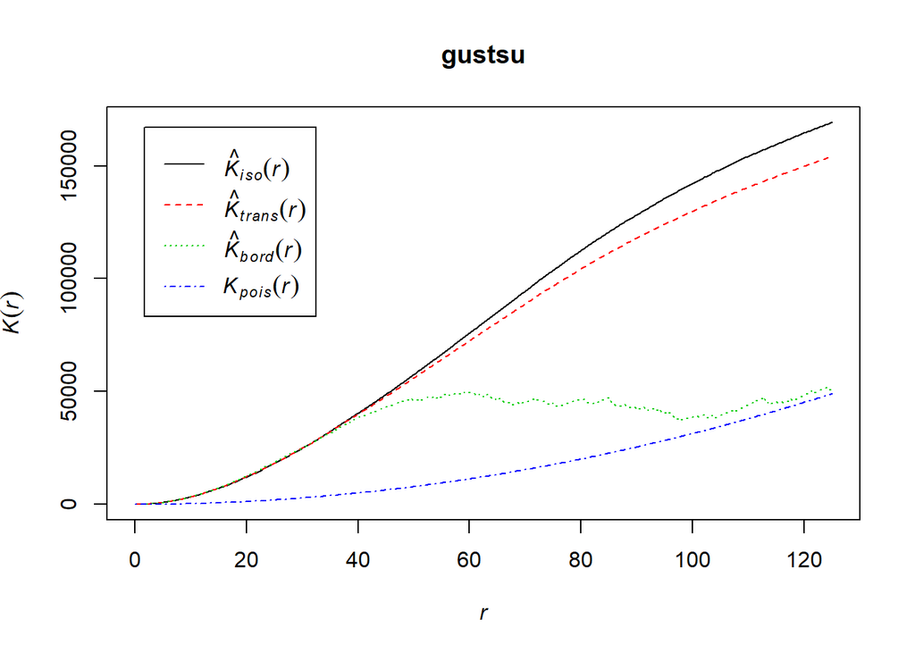

```r
sp_k<-Kest(sp1_pp, border="isotropic")
plot(sp_k, main=sp_names[s])
```

Now we generate the envelope to decide whether or not our data is different to the null model expectation. Although *spatstat* does have an envelope creating function there are better methods and we use the **rank envelope** function to generate the null model simulations.

```r
nsims<-2500
sp_env = envelope(sp1_pp, fun=Kest, nsim=nsims, savefuns=TRUE, global=TRUE, verbose=FALSE)
```

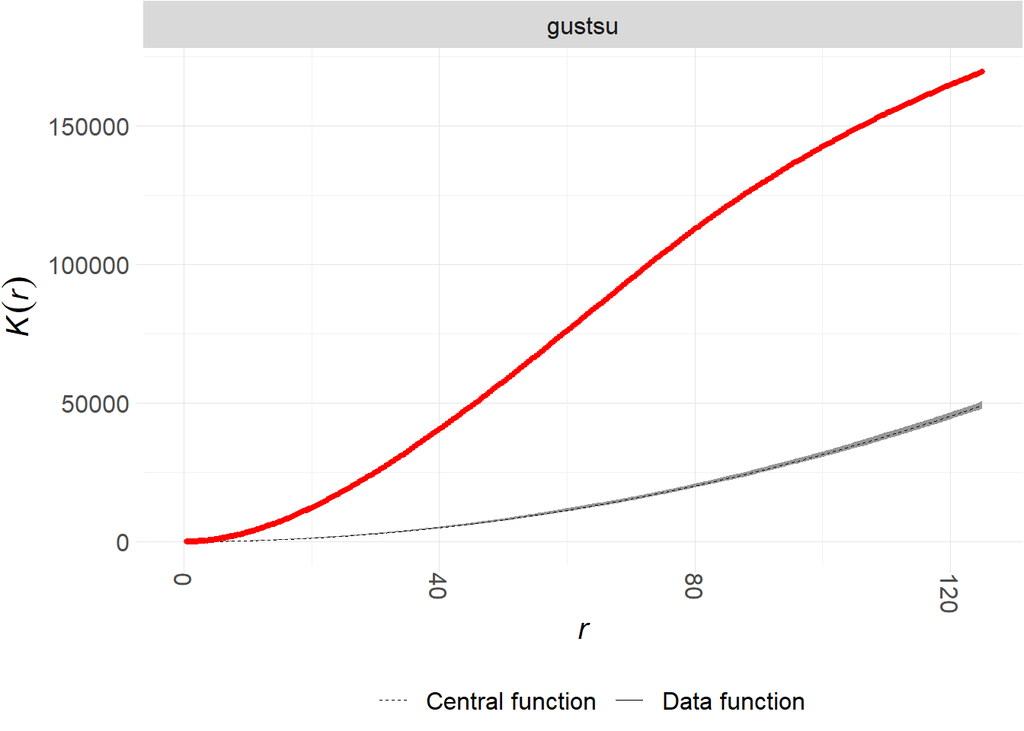

```r
res<-rank_envelope(sp_env)
plot(res, main=sp_names[s])
```

**What are your conclusions?**

### 5.4 Inhomogeneous processes

- *G. superba* is a species that is fast growing and exploits gaps that are created when large trees die and perhaps bring down other trees as they fall.
- You can see an area towards the north of the plot where there is a cluster of trees and this is probably due to a disturbance event a few decades ago (trees are very long lived). Because of this the **assumption of homogeneity is clearly violated**.
- **If** we have all the important covariates then we could fit a complicated model using a different approach. But we don’t have covariates here.
- However, we can take habitat preferences into account by using a **kernel density estimator** to create a surface that shows the local density. In 1 dimension,

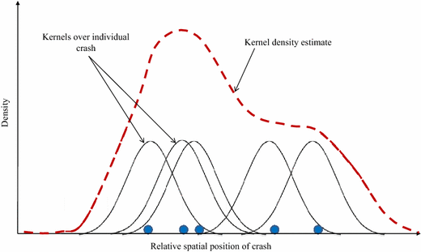

```r
knitr::include_graphics(".\\img\\spatialstats3\\kde.gif")
```

**Note** we have to decide the bandwidth of the smoothing function (often a Gaussian function or something similar).

We will use the Scott bandwidth estimator to automatically decide. We need two bandwidths

$w_x$ = $n \sigma(x)^ {-\frac{1}{6}}$  
$w_y$ = $n \sigma(y)^ {-\frac{1}{6}}$

- Now we ask if the trees are repelled or attracted to each other *given they have some preference(s) for certain regions of the plot*.
- In so doing we are separating out the effect of the abiotic environment and the effect of interactions and seed dispersal on the pattern of trees.
- We will use the **L-function** for this next part, but it is merely a transformed version of the K-function which has nicer properties (including having a smaller variation in scale of values which makes plotting better).

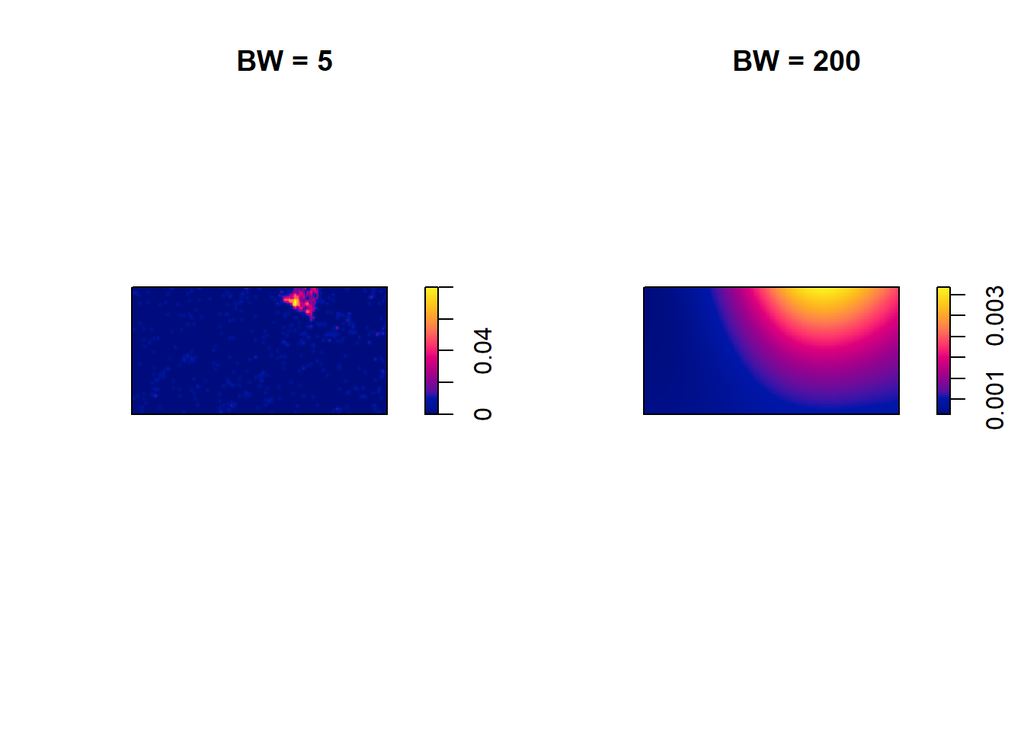

```r
par(mfrow=c(1,2))
smo<-density(sp1_pp, sigma=c(5,5))
#Plot the density surface
  plot(smo, main="BW = 5")

smo<-density(sp1_pp, sigma=c(200,200))
#Plot the density surface
  plot(smo, main="BW = 200")
```

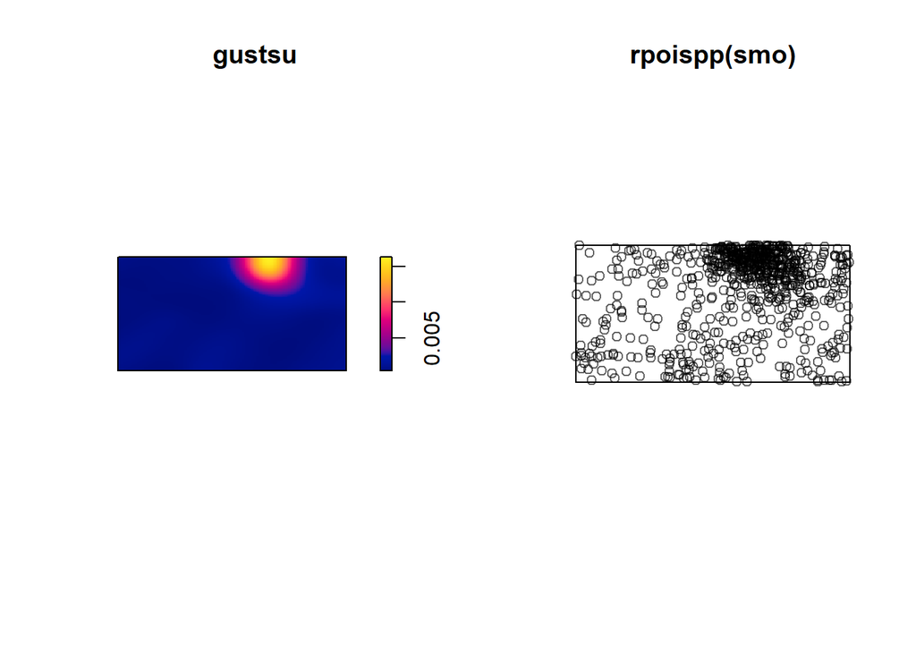

```r
#compute the density surface
  smo<-density(sp1_pp, sigma=bw.scott)
#Plot the density surface
  plot(smo, main=sp_names[s])



#Now generate an example null model pattern
plot(rpoispp(smo))
```

```r
#Compute the L-function of the data using the kernel density
inhom<-Linhom(sp1_pp, sigma=bw.scott, border="isotropic", nlarge = 100000)

#Create a matrix to hold the L-functions from the simulated datasets
cs <-matrix(ncol=nsims, nrow=length(inhom$r))
```

```r
for(i in 1:nsims)
    {
#Here the null model that the trees are independent of one another given the density function is simulated a large number of times
    inh<-Linhom(rpoispp(smo), sigma=bw.scott, nlarge = 100000)

    cs[,i]<-inh$iso
    }
```

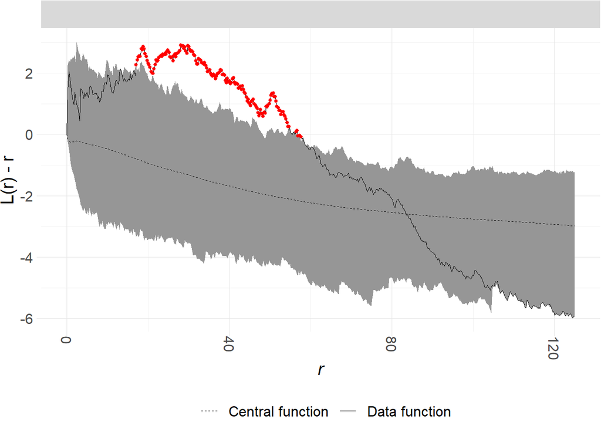

```r
#This next section just gets the data into the right format for the envelope test
r<-inh$r

obs<-inhom$iso - r
cs <- cs - r

c1<-list(r,obs, cs)
names(c1)=c("r","obs","sim_m")

cs1<-create_curve_set(c1)

#This is the part where the confidence interval envelope is created
res<-rank_envelope(cs1, central="mean")

#Plot the envelope and the data, and red denotes distances where the data is likely more extreme than if the trees were independent of one another
plot(res, main="", ylab="L(r) - r")
```

**What are your conclusions now?**

## 6. Further tasks

Try running the analyses again, but this time investigating species 2 in the list, **Virosu**, which is the hardwood tree *Virola surinamensis*. Now compare the test assuming homogeneity with the inhomogeneous test -what are your conclusions?

Feel free to investigate some of the other 300 species….

## 7. Further Reading

1. https://training.fws.gov/courses/references/tutorials/geospatial/CSP7304/documents/PointPatterTutorial.pdf –this is a great guide to analyzing point patterns in spatstat. It also discusses how to fit specific models to data and include covariates (eg elevation, soil charactersistics for the forest plot data above).
2. Papers on rank envelopes:
   - Myllymaki, M., Mrkvicka, T., Grabarnik, P., Seijo, H., & Hahn, U. ( 2017). Global envelope tests for spatial processes. Journal of the Royal Statistical Society Series B‐Statistical Methodology, 79, 381– 404. https://doi.org/10.1111/rssb.12172
   - Murrell, DJ. A global envelope test to detect non‐random bursts of trait evolution. Methods Ecol Evol. 2018; 9: 1739– 1748. https://doi.org/10.1111/2041-210X.13006